# Schwanensee

Mit den Mitteln des klassischen Tanzes erzählt SCHWANENSEE die Geschichte von Prinz Siegfried und seiner Liebe zu der verzauberten Prinzessin Odette, die in Schwanengestalt gefangen ist. Bald Schwan bald Mensch ist es ihre Bestimmung, Gegenstand der Phantasien des unglücklichen Prinzen zu sein. In der Interpretation von Patrice Bart ist es Siegfrieds Mutter, die ihren Sohn abgöttisch liebt und alle Fäden seines Schicksals in der Hand hält. Ohne Skrupel manipuliert sie seinen Freund Benno und benutzt Premierminister Rotbart als Erfüllungsgehilfen. In Anlehnung an die Epoche der Romanows im russischen Zarenreich macht sich in dieser Inszenierung eine beklemmende Untergangsstimmung breit, die von der unguten Mischung aus emotionaler Kälte und Dekadenz geprägt ist. Zuflucht findet der junge Prinz in der Begegnung mit den Schwänen.

Die faszinierende Wirkung der mächtigen Vögel kommt in den groß angelegten Schwanenbildern des Balletts zum Ausdruck, die choreographisch von den archaischen Flugformationen und ihrer natürlichen, zugleich unwirklichen Schönheit inspiriert sind. Mit den Tutus der Tänzerinnen, die das weiße Federkleid der Tiere nachempfinden, sind diese imposanten Szenen zum Inbegriff des klassischen Balletts geworden.

Zum Mythos geworden ist SCHWANENSEE aber auch wegen der Musik von Peter I. Tschaikowsky, der den gegensätzlichen Stimmungen ihren unverwechselbaren Klang verleiht: Sei es die Sehnsucht, die Prinz Siegfried und Odette zueinander finden lässt, oder der trügerische Glanz der Ballszenen, in denen der ganze Hofstaat wie im Rausch der verführerischen Odile verfällt, die als Doppelgängerin Odettes den Prinzen zu dem tragischen Schwur verleitet, mit dem er seine aufrichtige Liebe verrät. In dieser Spielzeit kehrt die Produktion auf die große Bühne der Staatsoper Unter den Linden zurück, es musiziert die Staatskapelle Berlin.

## Termine

So. 25. Dezember 2022 16.00 Uhr

[Staatsoper Unter den Linden](https://www.staatsoper-berlin.de/de/ihr-besuch/anfahrt/staatsoper-unter-den-linden.35/)

[Tickets](https://staatsoper-berlin.eventim-inhouse.de/webshop/webticket/shop?language=de&event=16541)

[Termin speichern](https://www.staatsoper-berlin.de/de/spielplan/59949/ics)

Dauer: 170 Minuten inkl. 1 Pause

## Besetzung

- Choreographie und Inszenierung: Patrice Bart
- Bühnenbild und Kostüme: Luisa Spinatelli
- Dramaturgie: Dr. Christiane Theobald
- Einstudierung: Raffaella Renzi
- Musikalische Leitung: Paul Connelly
- Es spielt: Staatskapelle Berlin
- Odette/Odile: Iana Salenko
- Siegfried: Daniil Simkin
- Königin: Aya Okumura
- Rotbart: Dinu Tamazlacaru
- Benno: Murilo de Oliveira
- Solist:innen und Corps de ballet des Staatsballetts Berlin

## Medien

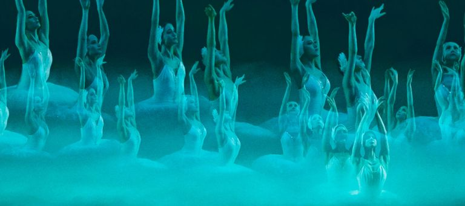

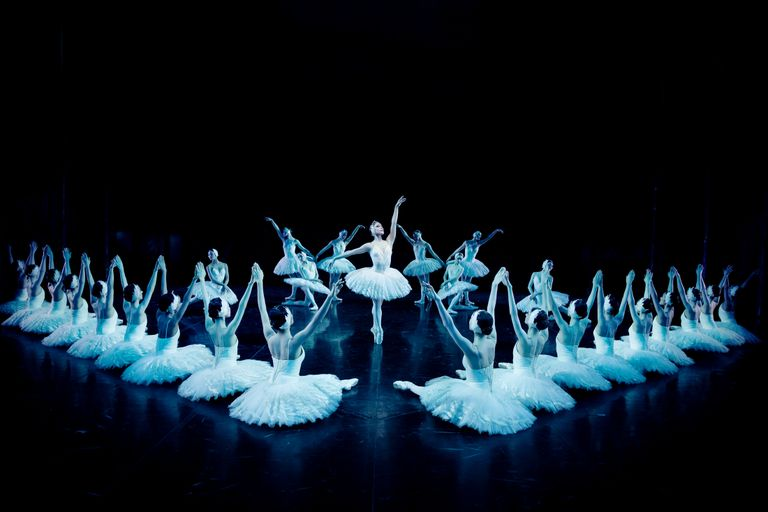